# Exploratory Data Analysis

Amelia

1/30/2017

## Fine Particulate Matter Polluion in the United States

The overall goal of this assignment is to explore the National Emissions Inventory database and see what it say about fine particulate matter pollution in the United states over the 10-year period 1999-2008.

```r
## Data Preprocessing
library(dplyr)
library(ggplot2)
NEI <- readRDS("summarySCC_PM25.rds")
SCC <- readRDS("Source_Classification_Code.rds")
```

The following questions and tasks will be addressed in this exploratory analysis:

### 1. Have total emissions from PM2.5 decreased in the United States from 1999 to 2008? Using the base plotting system, make a plot showing the total PM2.5 emission from all sources for each of the years 1999, 2002, 2005, and 2008.

```r
totalemissions<-tapply(NEI$Emissions, NEI$year, sum)
totalemissions
```

```
##    1999    2002    2005    2008
## 7332967 5635780 5454703 3464206
```

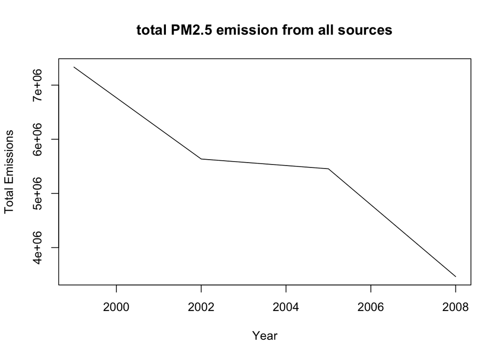

```r
plot(c(1999, 2002, 2005, 2008), totalemissions,
     xlab = "Year", ylab = "Total Emissions", "l",
     main = "total PM2.5 emission from all sources")
```

### Answer: Yes there is a decrease.

### 2. Have total emissions from PM2.5 decreased in the Baltimore City, Maryland (fips == “24510”) from 1999 to 2008? Use the base plotting system to make a plot answering this question.

```r
Bal.dat<-filter(NEI, fips=="24510")
Bal.tot<-tapply(Bal.dat$Emissions, Bal.dat$year, sum)
Bal.tot
```

```
##     1999     2002     2005     2008
## 3274.180 2453.916 3091.354 1862.282
```

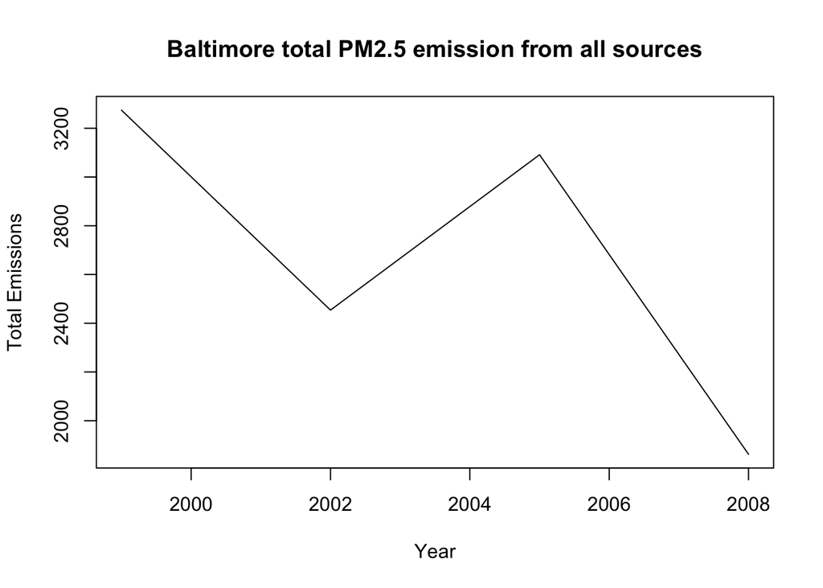

```r
plot(c(1999, 2002, 2005, 2008), Bal.tot,
     xlab = "Year", ylab = "Total Emissions", "l",
     main = "Baltimore total PM2.5 emission from all sources")
```

### Answer: There is an overall decrease from 1999 to 2008 but there is an increase from 2002 to 2005.

### 3. Of the four types of sources indicated by the type (Point, nonpoint, on-road, non-road) variable, which of these four sources have seen decreases in emissions from 1999???2008 for Baltimore City? Which have seen increases in emissions from 1999-2008? Use the ggplot2 plotting system to make a plot answer this question.

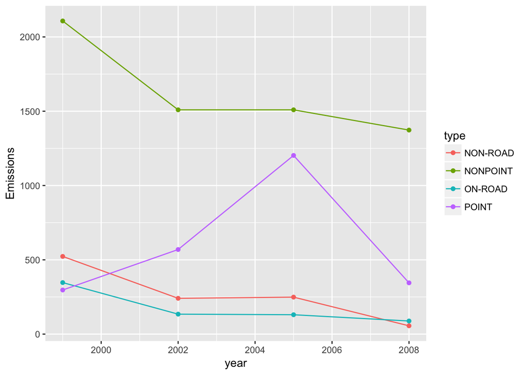

```r
Bal.type <- aggregate(Emissions ~ year + type, Bal.dat, sum)

g<-qplot(year, Emissions, data = Bal.type, color=type)
plot3<-g+geom_line()
print(plot3)
```

### 4. Across the United States, how have emissions from coal combustion-related sources changed from 1999-2008?

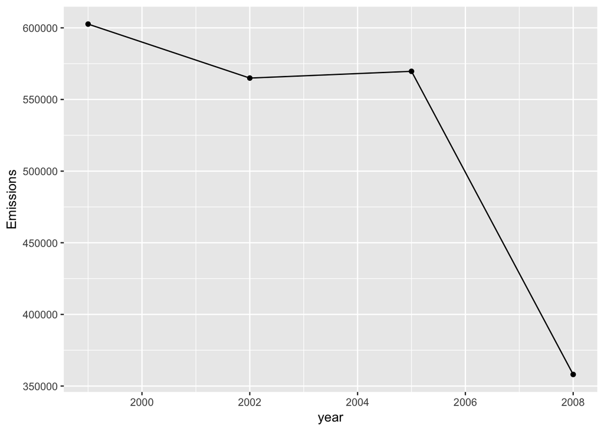

```r
fulldat<-merge(NEI, SCC, by = "SCC")
coaldat<-fulldat[grep("coal", fulldat$Short.Name,ignore.case = TRUE),]
coaltot <- aggregate(Emissions ~ year, coaldat, sum)

plot4<-qplot(year, Emissions, data=coaltot)+geom_line()
print(plot4)
```

### Answer: Emissions from coal combustion-related sources has decreased sharply.

### 5. How have emissions from motor vehicle sources changed from 1999-2008 in Baltimore City?

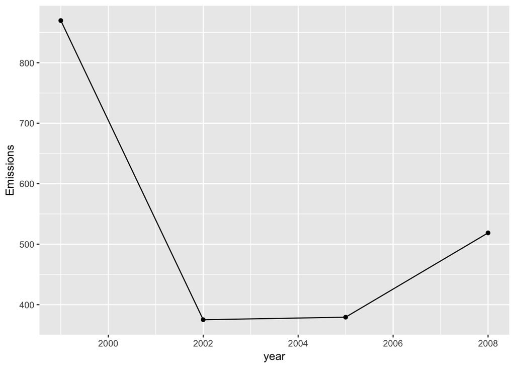

```r
full.Bal.dat<-filter(fulldat, fips=="24510")
Bal.veh<-full.Bal.dat[grep("Mobile", full.Bal.dat$EI.Sector,ignore.case = TRUE),]
Bal.veh.tot <- aggregate(Emissions ~ year, Bal.veh, sum)

plot5<-qplot(year, Emissions, data=Bal.veh.tot)+geom_line()
print(plot5)
```

### Answer: Emissions have decreased sharply from 1999 to 2002 and maintained at a low level from 2002 to 2005, but rose slightly in 2008.

### 6. Compare emissions from motor vehicle sources in Baltimore City with emissions from motor vehicle sources in Los Angeles County, California (fips == “06037”) Which city has seen greater changes over time in motor vehicle emissions?

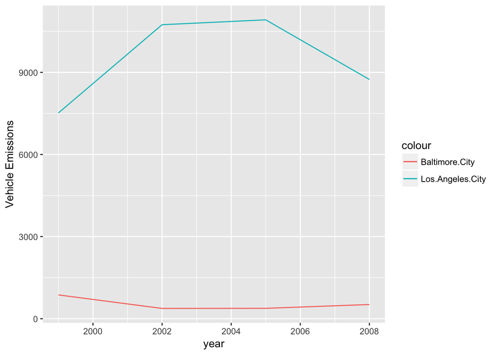

```r
full.LAC.dat<-filter(fulldat, fips=="06037")
LAC.veh<-full.LAC.dat[grep("Mobile", full.LAC.dat$EI.Sector,ignore.case = TRUE),]
LAC.veh.tot <- aggregate(Emissions ~ year, LAC.veh, sum)
mergedat<- merge(LAC.veh.tot, Bal.veh.tot, by = "year")
names(mergedat)<-c("year", "Los.Angeles.City", "Baltimore.City")

plot6<-ggplot(data = mergedat, aes(x=year)) +
  geom_line(aes(y = Los.Angeles.City, colour = "Los.Angeles.City")) +
  geom_line(aes(y = Baltimore.City, colour = "Baltimore.City")) +
  ylab("Vehicle Emissions")
print(plot6)
```

### Answer: Los Angeles City has seen greater changes